# Simulation results

### r

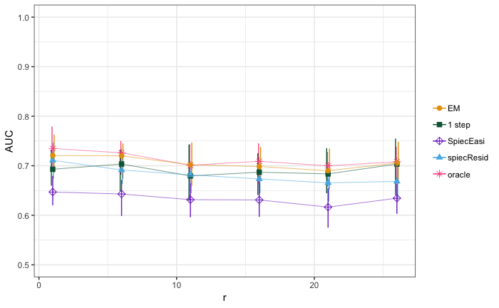

```r
type<-"cluster/"
param<-"r/"
bright_graph(type=type,param=param)
```

### d

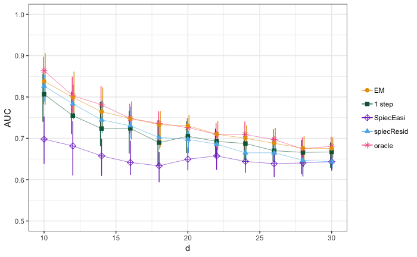

```r
type<-"cluster/"
param<-"d/"
bright_graph(type=type,param=param)
```

### n

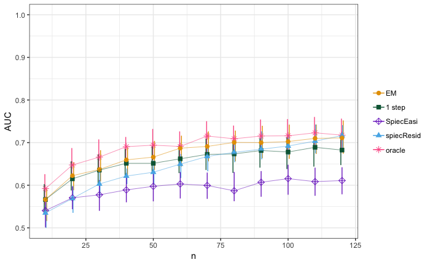

```r
type<-"cluster/"
param<-"n/"
bright_graph(type=type,param=param)
```

## Tree

### d

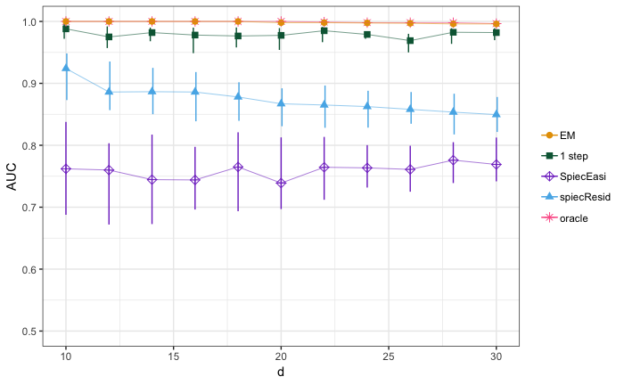

```r
type<-"tree/"
param<-"d/"
bright_graph(type=type,param=param)
```

### n

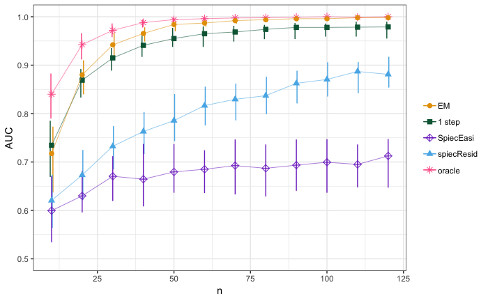

```r
type<-"tree/"
param<-"n/"
bright_graph(type=type,param=param)
```

## Scale-free

### d

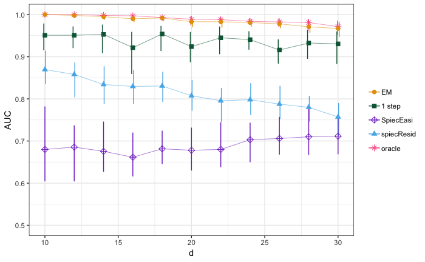

```r
type<-"scale-free/"
param<-"d/"
bright_graph(type=type,param=param)
```

### n

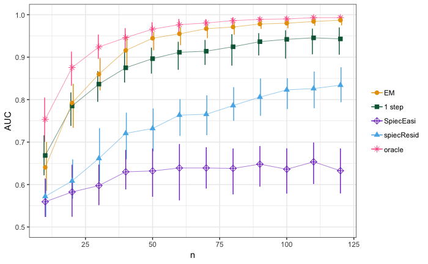

```r
type<-"scale-free/"
param<-"n/"
bright_graph(type=type,param=param)
```

# Precision Recall

## Table

Data about precresion/recal criteria has been extracted from simulations under frames “precrec.auc”, in each files. Column names are not straightforward:

- `var` is the value of the parameter (ex: 10 nodes)
- `param` is the graph number

```r
precrec <- as_tibble(readRDS("~/simulations/Simu/PLNcov/erdos/d/precrec.rds"))
precrec
```

|  | prec | rec | method | var | B | param |
| --- | --- | --- | --- | --- | --- | --- |
| 1 | 1.0000000 | 0.11111111 | treeggm | 10 | 1 | 1 |
| 2 | 1.0000000 | 0.22222222 | treeggm | 10 | 2 | 1 |
| 3 | 1.0000000 | 0.33333333 | treeggm | 10 | 1 | 1 |
| 4 | 1.0000000 | 0.44444444 | treeggm | 10 | 2 | 1 |
| 5 | 1.0000000 | 0.55555556 | treeggm | 10 | 1 | 1 |
| 6 | 1.0000000 | 0.66666667 | treeggm | 10 | 2 | 1 |
| 7 | 1.0000000 | 0.77777778 | treeggm | 10 | 1 | 1 |
| 8 | 0.8750000 | 0.77777778 | treeggm | 10 | 2 | 1 |
| 9 | 0.7777778 | 0.77777778 | treeggm | 10 | 1 | 1 |
| 10 | 0.7000000 | 0.77777778 | treeggm | 10 | 2 | 1 |

[output cut: 990 more lines]

## Figures on all genrated graphs

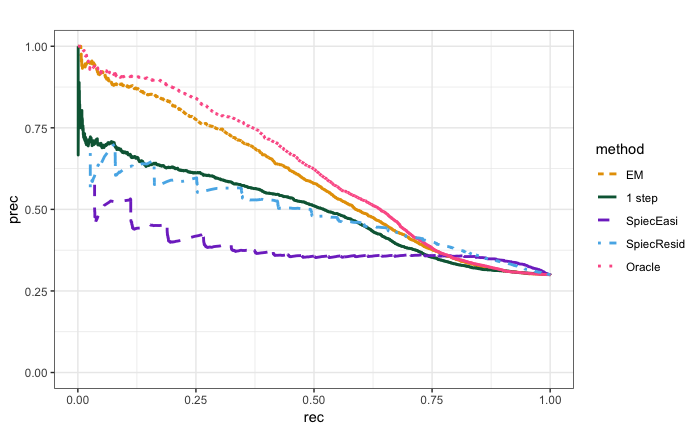

Mosaic plot of Precision/Recal curves for different values of the parameter (here number of nodes is 10, 16, 20 or 30), summary results on all generated graphs.

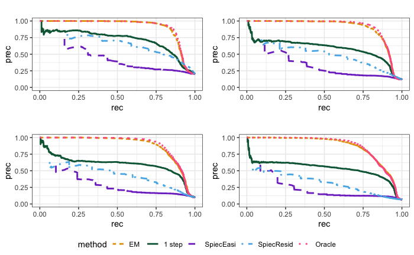